# Question

Two concentric circles have radii $r_1=1$ meters and $r_2=4.01$ meters. A central angle subtends similar arcs on both circles: a blue arc on the smaller circle and a red arc on the larger circle. The red arc length is 3.29 meters, as shown in the diagram below.

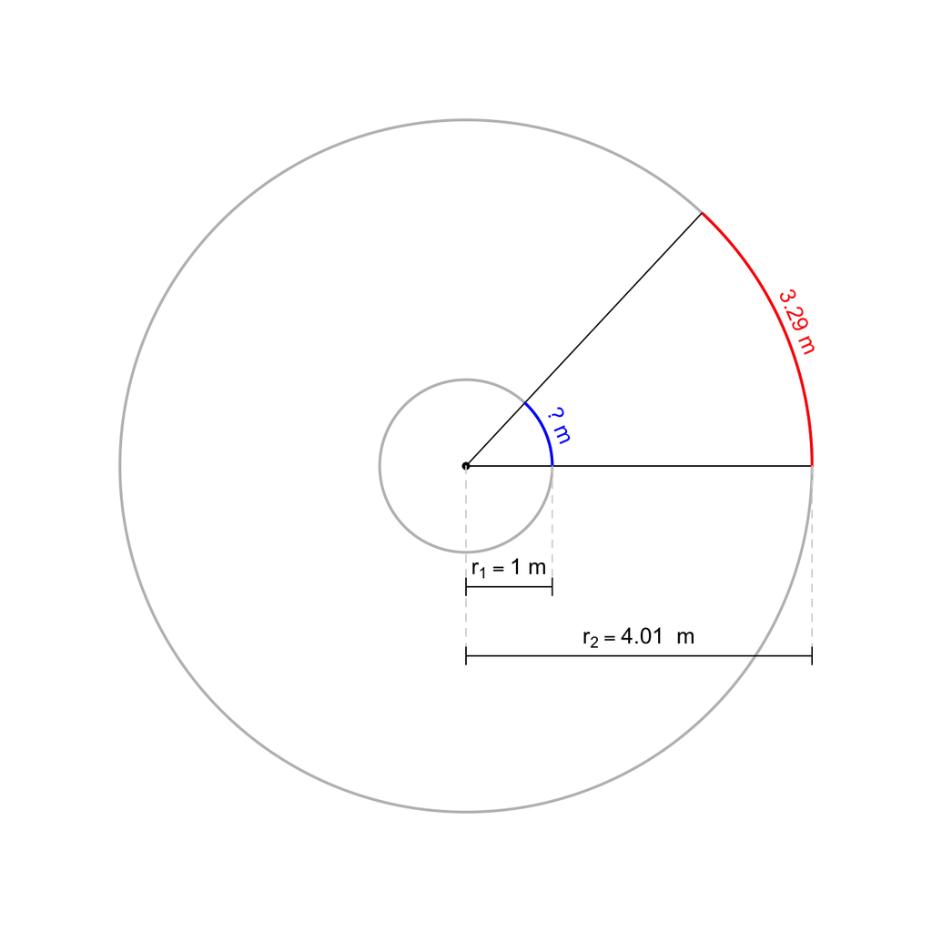

What is the length, in meters, of the blue arc? *The tolerance is set to $\pm0.01$ meters.*

# Solution

Okay, this might seem absurdly easy if you are comfortable with similarity.

$$\frac{1}{?} ~=~
\frac{4.01}{3.29}$$

$$?~=~ \frac{3.29}{4.01} ~=~
0.8204489$$

I am trying to introduce the **[radian](https://en.wikipedia.org/wiki/Radian)**, which is the arc length of a unit circle.

- Massachusetts learning objective F-TF.A.1:
  - Understand radian measure of an angle as the length of the arc on the unit circle subtended by the angle.

If you look up [circular arc](https://en.wikipedia.org/wiki/Circular_arc#Length) on wikipedia, you’ll see a formula relating the arc length ($L$) to radius ($r$) and the central angle **measured in radians** ($\theta$).
$$L~=~r\theta$$

So, in our case:

$$3.29~=~(4.01)(\theta)$$

$$\theta~=~\frac{3.29}{4.01}~=~
0.8204489$$

# Meta-information

extype: num exsolution: 0.8204489 exname: radians_from_r_L extol: 0.01